# One4All_LA14

Braden Griebel, Luke Fanning, Ayho Falick, Andrew Duffy

12/4/2019

```r
perm_mean <- function(perms = 1000, all_values, n_A)
{
  ## Variables ##
  # perms: The number of permutations
  # all_values (num): all data values
  # n_A (int): Size of group A
  ###############

  # Step 1:
  # Create vector of zeroes of length "perms" to store
  # permuted mean differnces
  permuted_mean_differences<-rep(0,perms)

  # Loop throught number of permutations
  for (i in c(1:perms))
  {
    # Step 2:
    # Randomly separate vector "values" into disjoint
    # groups of size "nA" and "nB" respectively
    temp<-sample(all_values)
    group_A<-temp[1:n_A]
    group_B<-temp[(n_A+1):length(temp)]

    # Step 3:
    # Compute the sample means for the two groups from
    # step 2
    mean_A<-mean(group_A,na.rm=T)
    mean_B<-mean(group_B,na.rm=T)


    # Step 4:
    # Compute the difference in sample means, store the
    # value in the vector from step 1
    permuted_mean_differences[i]<-mean_A-mean_B

  }

  # Step 5:
  # Return the permuted mean differences vector
  return(permuted_mean_differences)

}
```

```r
perm_cor <- function(perms = 1000, x, y)
{
  ## Variables ##
  # perms: The number of permutations
  # x: Vector of Variable 1 - for computing correlation
  # y: Vector of Variable 2 - for computing correlation
  ###############

  # Step 1:
  # Create vector of zeroes of length "perms" to store
  # permuted mean differnces
  correlations<-rep(0,perms)


  # Loop throught number of permutations
  for (i in c(1:perms))
  {
    # Step 2:
    # Randomly mix up the values in the vector "y"
    temp<-sample(y)

    # Step 3:
    # Compute the correlation between x and the randomly mixed
    # up y-vector. Store this value in the vector from step 1.
    correlations[i]<-cor(x,temp,use="pairwise.complete.obs")

  }

  # Step 4:
  # Return new updated vector, created in step 1
  return(correlations)

}
```

```r
cdc
```

```
## # A tibble: 20,000 x 9
##    genhlth   exerany hlthplan smoke100 height weight wtdesire   age gender
##    <fct>       <dbl>    <dbl>    <dbl>  <dbl>  <int>    <int> <int> <fct>
##  1 good            0        1        0     70    175      175    77 m
##  2 good            0        1        1     64    125      115    33 f
##  3 good            1        1        1     60    105      105    49 f
##  4 good            1        1        0     66    132      124    42 f
##  5 very good       0        1        0     61    150      130    55 f
##  6 very good       1        1        0     64    114      114    55 f
##  7 very good       1        1        0     71    194      185    31 m
##  8 very good       0        1        0     67    170      160    45 m
##  9 good            0        1        1     65    150      130    27 f
## 10 good            1        1        0     70    180      170    44 m
## # ... with 19,990 more rows
```

```r
tdata<-cdc%>%mutate(hlthcoded=ifelse(genhlth=="excellent",5,
                                     ifelse(genhlth=="very good",4,
                                            ifelse(genhlth=="good",3,
                                                   ifelse(genhlth=="fair",2,
                                                          ifelse(genhlth=="poor",1,NA))))))
```

## Team Question:

How does smoking affect General Health when accounting for age?

### Importance:

This is important, because although people now know that smoking can cause cancer, it is not neccesarily well known whether smoking affects other aspects of health. This analysis will allow us to see whether there affects on the general health based on smoking. Additionally, since we will be taking age into account, we don’t have to worry about this variable confusing the matter. If we can understand how general health is affected by smoking we can understand how important smoking is when considering how healthy someone is likely to be. This can be used by the government to institute policies relating to this. Since many people, especially young people, seem less concerned about the long term probability of cancer increasing due to smoking, understanding how it affects current general health could be important in convincing more people to stop smoking. So ultimately, this question is important because it allows us to understand how general health is affected by smoking. This in turn is important, becuase understanding how smoking affects general health can allow the government to make policies, and determine whether spending more money on programs to discourage smoking would be effective in improving the general health of the population. Improving the general health of a population would likely increase the overall happiness of the society, decrease the amount of money the government has to spend on health programs and increase the economic stability of the general populace (given that medical debt is one of the leading causes of bankrupcy in the US).

### Generalised Linear Model

```r
modelsmoke<-glm(smoke100~hlthcoded+age,family=binomial,data=tdata)
tdata<-add_predictions(tdata,modelsmoke)%>%mutate(psmoke=exp(pred)/(1+exp(pred)))
#tdata
smoking_probabilities<-cdc%>%group_by(genhlth)%>%summarise("Probability of Smoking"=mean(smoke100))%>%rename("General Health"=genhlth)
smoking_probabilities
```

```
## # A tibble: 5 x 2
##   `General Health` `Probability of Smoking`
##   <fct>                               <dbl>
## 1 excellent                           0.382
## 2 very good                           0.461
## 3 good                                0.510
## 4 fair                                0.549
## 5 poor                                0.662
```

```r
age_smoking_prob<-cdc%>%group_by(genhlth,age)%>%summarize(probability=mean(smoke100))
coef(modelsmoke)
```

```
## (Intercept)   hlthcoded         age
##  0.20270993 -0.21033490  0.01000258
```

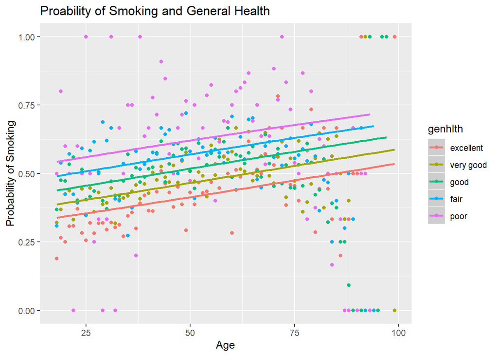

```r
ggplot(tdata,aes(age,psmoke))+geom_point(data=age_smoking_prob,aes(age,probability,color=genhlth))+geom_smooth(aes(color=genhlth))+labs(y="Probability of Smoking",x="Age",title="Proability of Smoking and General Health")#+facet_wrap(~genhlth)
```

### Finding:

As can be seen from the probability calculations, as people decrease in general health they have a higher probability of having smoked. Additionally, from the generalised linear models we can examine the effect that age and general health have on the probability of smoking. Note, that these models generate a logodds, not an actual probability. However, since logodds is a monotomically increasing function on probability, we can still interpret the signs on the coefficients as influencing the probability. As health increases (from poor to excellent) the health coded increases, so we can just treat this as a measure of health. The sign of the coefficient for the health coded term is negative, meaning that those with better health have a lower probability of smoking (when taking age into account). Since the age term has a positive sign associated with it the probability of smoking increases with age (which makes sense given how much effort has been put into decreasing smoking over the years, and how popular it used to be). What this means, is that those who have smoked have a higher probability of being in a worse health category.

### Permutation Test:

Is there a difference in the general health between smokers and non-smokers? $H_0:\mu_{General\ Health\ of \ non-smokers}-\mu_{General\ Health\ of \ smokers}=0$  
$H_1:\mu_{General\ Health\ of \ non-smokers}-\mu_{General\ Health\ of \ smokers}\neq0$

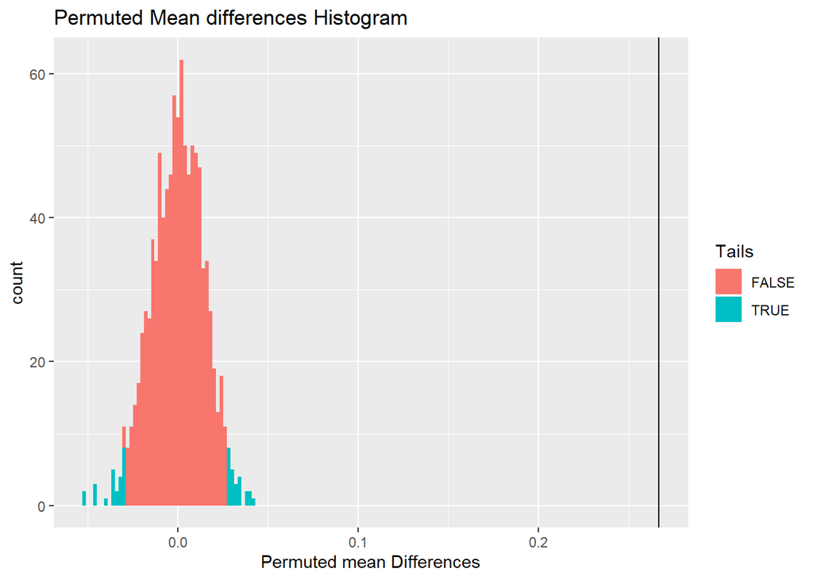

```r
smokers<-tdata%>%filter(smoke100==1)
nonsmokers<-tdata%>%filter(smoke100==0)
smoke_calc_mean_diff<-mean(nonsmokers$hlthcoded)-mean(smokers$hlthcoded)
smokepermuted<-tibble(differences=perm_mean(perms=1000,all_values = tdata$hlthcoded,n_A = nrow(nonsmokers)))
ggplot(data=smokepermuted,aes(differences))+
  geom_histogram(binwidth=.002,aes(fill=(differences<quantile(differences,probs = c(.025))[[1]]|differences>quantile(differences,probs = c(.975))[[1]])))+
  labs(title="Permuted Mean differences Histogram",fill="Tails",x="Permuted mean Differences")+
  geom_vline(xintercept=smoke_calc_mean_diff)+labs()
```

```r
percentile=nrow(filter(smokepermuted,differences<smoke_calc_mean_diff))/nrow(smokepermuted)
tibble(Percentile=percentile)
```

```
## # A tibble: 1 x 1
##   Percentile
##        <dbl>
## 1          1
```

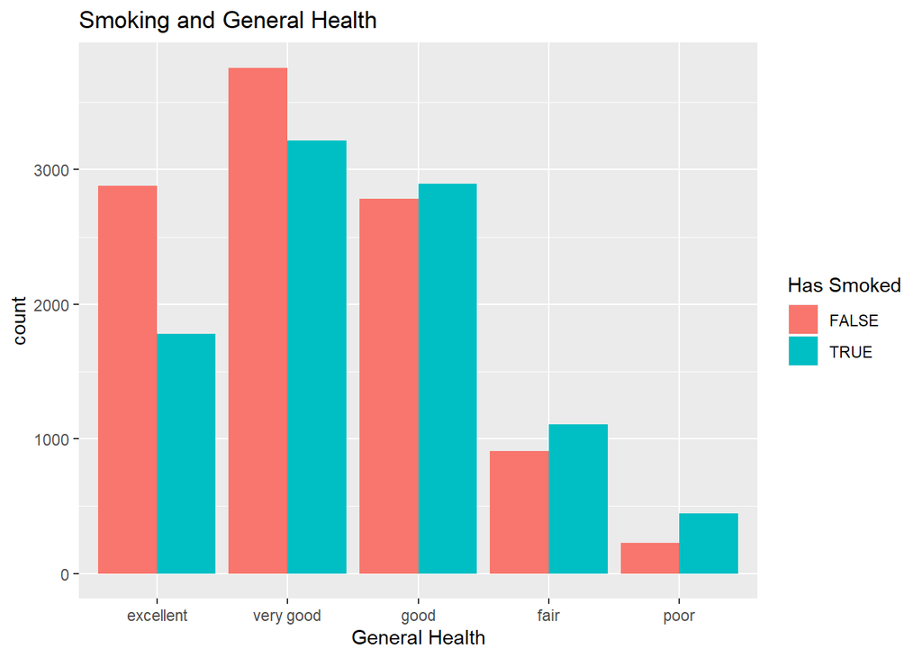

```r
cdc_modified<-cdc%>%mutate(smoke100L=as.logical(smoke100))%>%mutate(hlthcoded=ifelse(genhlth=="excellent",5,
                                     ifelse(genhlth=="very good",4,
                                            ifelse(genhlth=="good",3,
                                                   ifelse(genhlth=="fair",2,
                                                          ifelse(genhlth=="poor",1,NA))))))
ggplot(data=cdc_modified,aes(genhlth,fill=smoke100L))+geom_bar(position="dodge")+labs(title="Smoking and General Health",fill="Has Smoked",x="General Health")
```

### Findings:

Since the real calculated mean difference between the mean general health of smokers, and that of non smokers is far into the tail of the permuted graph we can reject the null and acceptt the alternative hypothesis. This is also backed up by the fact that it has a percentile of 1, so the difference is greater than any of the randomly permuted difference of means. Clearly then, the labels of smoker and non-smoker really do make a difference to general health. Also, note that since it is far to the right, non-smokers seem to have higher general health than the non-smokers. All of this is further backed up by the graph showing that there is a higher number of non-smokers in the higher health category, and higher numbers of smokers in the lower health categories.

### Conclusion:

From the generalised linear model, it can be seen that even when accounting for age, smoking is still less likely as the general health category increases. From the permutation test, it is clear that the differencce in general health between smokers and non-smokers is significantly different. All of this is backed up by the last graph showing that those who don’t smoke are more likely to be in the higher health categories, while those that do smoke are more likely to be in a lower health cateogry. This is backed up by the earlier probability calculations. Taking this all together, we can see that smoking is detrimental to general health even when accounting for age.

### Recomendation:

Thus we know that smoking generally decreases the general health of the person smoking. So beyond just increasing the risk of cancer, it also decreases health across the board. With this in mind, we recomend that it is made clear that smoking not only increases the probability of cancer, but also decreases general health across the course of a lifetime. We would encourage spending in programs that increase the knowledge of this aspect of smoking. Also, increased spending on any programs which seem to decrease the proportion of people that smoke. In order to do this it would be important to understand what types of programs are most effective at decreasing the number of people which smoke (and doing a cost-benefit analysis on these).

### Some Ethical Cnsiderations:

Insurance companies could use this analysis to increase the premiums and rates that smokers have to pay. Although, this would likely benefit the insurance company it would hurt people who are smokers or who have smoked because they will have to pay more for health insurance.

## Braden Griebel Individual Section:

### Question:

How are weight desire and weight related, and does this vary between the general health groups? ### Importance: This question is important because it allows me to understand how general health is related to weight and weight desire (specifically their difference). Understanding this could be useful, because it would allow me to gain some understanding of the phycolpogical aspects of general health and weight loss. For example, if we were to find that as general health increases, the difference between weight and weight desired decreases, this could be because across the board pepole want to weigh in a certain range and that more unhealthy people are just father away from this range. However, it could also indicate that healthier people have more realistic goals which help them get to more healthy weights thus increasing their health. Whatever the result, more analysis would be neccesary to see what the difference actually means. But this question is a good initial inroad to this knotty problem.

### Linear Models

```r
bdata<-cdc%>%mutate(wtdiff=weight-wtdesire)%>%group_by(genhlth)%>%nest()
bmodel<-function(df){lm(formula = wtdesire~weight,data = df)}
bdata<-bdata%>%mutate("model"=map(bdata$data,bmodel))
bdata<-bdata%>%mutate(co=map(bdata$model,coef))
bdata<-bdata%>%mutate(predictions=map2(data,model,add_predictions))
bdata_predictions<-bdata%>%unnest(data,predictions,.drop=T)
bdata_predictions<-bdata_predictions%>%select(-(exerany1:gender1),-wtdiff1)
bdata<-bdata%>%mutate(slope=map_dbl(bdata$co,"weight"))
bdata_slopes<-bdata%>%select(genhlth,slope)
bdata_slopes
```

```
## # A tibble: 5 x 2
##   genhlth   slope
##   <fct>     <dbl>
## 1 good      0.611
## 2 very good 0.706
## 3 excellent 0.786
## 4 fair      0.515
## 5 poor      0.356
```

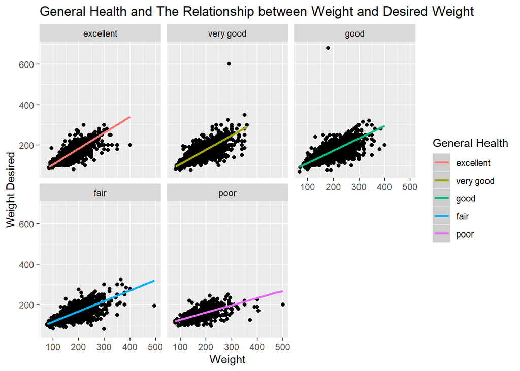

```r
ggplot(bdata_predictions)+geom_point(aes(weight,wtdesire))+
  facet_wrap(~genhlth)+
  geom_smooth(aes(weight,pred,color=genhlth))+
  labs(title="General Health and The Relationship between Weight and Desired Weight", y="Weight Desired",x="Weight",color="General Health")
```

### Findings: As you go down in health, the slope of the relationship between weight and desired weight decreases, from a maximum slope of .7855 down to .356. This is indicative of the fact tht those in the better health categories are significantly closer to their desired weight than those in the lower health categories.

### Permutation Test

Is there a differnce in the mean weight distance from desired weight? $H_0$:$\mu_{Good\ Health\ Weight\ Difference}-\mu_{Poor\ Health\ Weight\ Difference} =0$ $H_1$:$\mu_{Good\ Health\ Weight\ Difference}-\mu_{Poor\ Health\ Weight\ Difference} \neq 0$

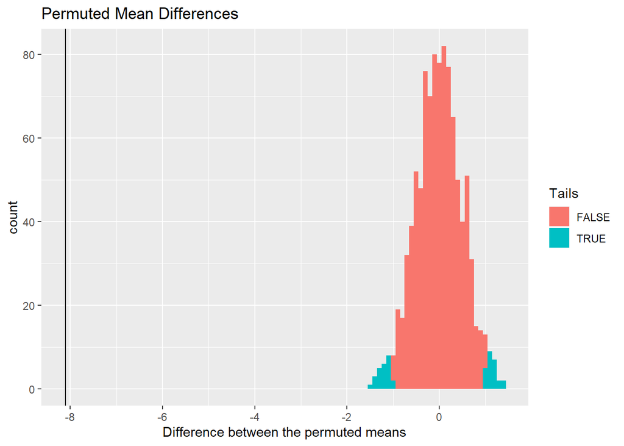

```r
b2data<-cdc%>%mutate(wtdiff=weight-wtdesire)
good_health<-b2data%>%filter(genhlth %in% c("good","very good","excellent"))
poor_health<-b2data%>%filter(genhlth %in% c("fair", "poor"))
calculated_mean_diff<-mean(good_health$wtdiff)-mean(poor_health$wtdiff)
combined_vector<-c(good_health$wtdiff,poor_health$wtdiff)
permuted_mean_difference<-tibble(differences=perm_mean(perms=1000,all_values=combined_vector,n_A=nrow(good_health)))
ggplot(data=permuted_mean_difference,aes(differences))+
  geom_histogram(binwidth=.1,aes(fill=(differences<quantile(differences,probs = c(.025))[[1]]|differences>quantile(differences,probs = c(.975))[[1]])))+
  labs(title="Permuted Mean Differences",fill="Tails",x="Difference between the permuted means")+
  geom_vline(xintercept=calculated_mean_diff)
```

```r
percentile=nrow(filter(permuted_mean_difference,differences<calculated_mean_diff))/nrow(permuted_mean_difference)
tibble(Percentile=percentile,"Numerical Result"=calculated_mean_diff)
```

```
## # A tibble: 1 x 2
##   Percentile `Numerical Result`
##        <dbl>              <dbl>
## 1          0              -8.10
```

### Conclusion:

This questions was used to explore other factors that can affect, be affected by general health. Some people report smoking as an attempt to loose weight, or not desiring to quit because of a likely weight game. All of this means that my question is useful when considering the relationship between smoking and general health due to the relationship between general health and weight, and also weight and weight desires relationship to smoking. Moslty this question was used to explore how general health affects, or is affected by factors that are associated with smoking. The answer to the question is that healthier people tend to be closer to their desired weight, and that, based on the linear model, the relationship between weight and desired weight is much closer (slope nearer one) for healthier individuals. This is related to the main question in that it shows how weight and desired weight can affect or be affected by general health. It shows that general health has a relation to weight and weight desire, and due to the relationship that smoking has with weight and weight desire this is important to consider when thinking about the results to the team question.

I applied a permutation test in answering this question in order to see if there was a statistically significant difference in the difference between weight and weight desire between those with better and worse health. I also used a linear model to see how the relantionship between weight and desired weight differs between the general health categories.

## Luke Fanning Individual Section

### Question:

Is there a difference in mean weight difference (weight minus weight desire) between those who smoke and don’t smoke?

### Importance:

Obviously, many who smoke are in poorer health than those who don’t smoke, due to the obvious health problems created by smoking. However, while it is relatively obvious that many who smoke are less healthy overall (I.E. exercise less, have poorer general health, etc.), there is no evidence to suggest that these health drawbacks affect the mental viewpoint of those who smokewith regards to weight, represented through the difference in weight versus desired weight. Therefore, it would be interesting to see if smoking does in fact play a factor in having a larger or smaller mean weight difference.This is important to investigate, as it can help to better describe the mental image of the average smoker vs. the non-smoker, and can work to help those facing health problems from smoking see a clearer pattern of negative behaviorisms. It is also important to study this question as it can work to better describe the general populace of smokers to then help professionals working woth those facing smoke related health problems have a clearer picture of the populace they are attempting to help.

### Permutation Test:

*Null Hypothesis:* The mean weight difference is the same between smokers and non-smokers. *Alternative Hypothesis:* There is a difference in mean weight difference between smokers and non-smokers.

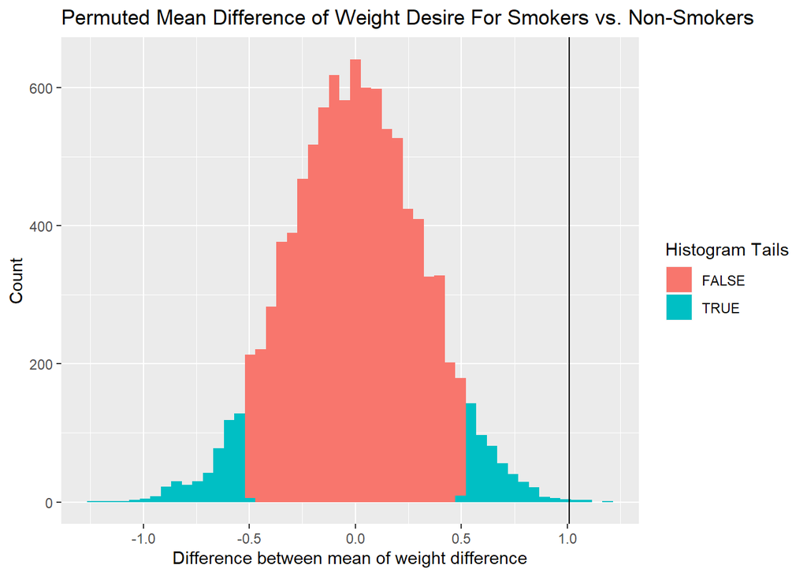

```r
ldata <- cdc %>% mutate(weightdifference = abs(weight-wtdesire))
smokers <- ldata %>% filter(smoke100 == 1)
non_smokers <- ldata %>% filter(smoke100 == 0)
real_mean_smoke_vs_non_smoke <- mean(smokers$weightdifference) - mean(non_smokers$weightdifference)
permuted_means <- perm_mean(10000, ldata$weightdifference, nrow(non_smokers))
percentile <- length(permuted_means[permuted_means < real_mean_smoke_vs_non_smoke])/10000
tibble(val = permuted_means) %>% ggplot(., aes(val)) + geom_histogram(bins = 50, aes(fill=(permuted_means<quantile(permuted_means,probs = c(.05))[[1]]|permuted_means>quantile(permuted_means,probs = c(.95))[[1]]))) + geom_vline(xintercept = real_mean_smoke_vs_non_smoke) + labs(title = "Permuted Mean Difference of Weight Desire For Smokers vs. Non-Smokers", x = "Difference between mean of weight difference", y = "Count", fill = "Histogram Tails")
```

### Findings:

As the difference between mean weight difference for smokers vs. non-smokers is in the 99.9th percentile of all mean weight differences, it is clear that there is a quantifiable difference between the mean weight differences for the two groups. The data clearly suggests that smokers have a larger difference between their current weight and desired weight than non-smokers, indicating that the apparent health problems caused by smoking also includes the mental perception of one’s weight. While this may not be a mental problem, and rather a physical problem simply caused by other health problems surrounding smoking which make it harder for a person to reach their desired weight, it is important to understand that this difference between smokers and non-smokers exists, as again, this can help professionals working to help those with smoking related health or mental health problems.

# Andrew Duffy subquestion

## Question:

### Using a permutation test, can you show that people who smoke are less healthy than non-smokers via the difference of weight and weight desire?

## Null Hypothesis:

### Smoking has no effect on health

since genhealth is not an exact measurement of health, we can measure one’s health with weight vs. weight desire. Weight is definitely not the only determinant of health, but if weight - weightdesire > 15, we can assume they are quite unhealthy becuase they would like to lose at least 15 pounds. Therefore, our test statistic will be the boolean variable measuring if they smoke or not

##Hypothesis 1: ### Smoking does have an effect on health.

I expect for this hypothesis to be proven true by the visual representation of the permutation test I will perform.

```r
perm_mean <- function(perms = 1000, all_values, n_A)
{
  ## Variables ##
  # perms: The number of permutations
  # all_values (num): all data values
  # n_A (int): Size of group A
  ###############

  # Step 1:
  # Create vector of zeroes of length "perms" to store
  # permuted mean differnces
  permuted_mean_differences<-rep(0,perms)

  # Loop throught number of permutations
  for (i in c(1:perms))
  {
    # Step 2:
    # Randomly separate vector "values" into disjoint
    # groups of size "nA" and "nB" respectively
    temp<-sample(all_values)
    group_A<-temp[1:n_A]
    group_B<-temp[(n_A+1):length(temp)]

    # Step 3:
    # Compute the sample means for the two groups from
    # step 2
    mean_A<-mean(group_A,na.rm=T)
    mean_B<-mean(group_B,na.rm=T)


    # Step 4:
    # Compute the difference in sample means, store the
    # value in the vector from step 1
    permuted_mean_differences[i]<-mean_A-mean_B

  }

  # Step 5:
  # Return the permuted mean differences vector
  return(permuted_mean_differences)

}
```

```r
perm_cor <- function(perms = 1000, x, y)
{
  ## Variables ##
  # perms: The number of permutations
  # x: Vector of Variable 1 - for computing correlation
  # y: Vector of Variable 2 - for computing correlation
  ###############

  # Step 1:
  # Create vector of zeroes of length "perms" to store
  # permuted mean differnces
  correlations<-rep(0,perms)


  # Loop throught number of permutations
  for (i in c(1:perms))
  {
    # Step 2:
    # Randomly mix up the values in the vector "y"
    temp<-sample(y)

    # Step 3:
    # Compute the correlation between x and the randomly mixed
    # up y-vector. Store this value in the vector from step 1.
    correlations[i]<-cor(x,temp,use="pairwise.complete.obs")

  }

  # Step 4:
  # Return new updated vector, created in step 1
  return(correlations)

}
```

```r
nonsmk <- cdc %>% filter(smoke100 == 0) %>% select(weight, smoke100, wtdesire)

realmean_ns <- mean((nonsmk$weight - nonsmk$wtdesire), na.rm = TRUE)

smk <- cdc %>% filter(smoke100 == 1) %>% select(weight, smoke100, wtdesire)

realmean_s <- mean((smk$weight - smk$wtdesire), na.rm = TRUE)
```

The real mean for weight - weight desire for non smokers is:

```r
realmean_ns
```

```
## [1] 14.45535
```

The real mean for weight - weight desire for smokers is:

```r
realmean_s
```

```
## [1] 14.73869
```

so, as you can see, smokers on average do want to lose more weight, signalling that they are more overweight. However, there is barely a difference between the two means.

Now, for the permutation test.

```r
permtib <- cdc %>% select(weight, wtdesire, smoke100)
permtib["difference"] <- (permtib$weight - permtib$wtdesire)
```

```r
perm_ns <- permtib %>% filter(smoke100 == 0)
perm_s <- permtib %>% filter(smoke100 == 1)   #I do this to figure out the size of each category, for n_A in perm test.

permtib <- permtib %>% arrange(smoke100 == 0)

permtest_val <- perm_mean(perms = 1000, permtib$difference, 9441)
```

```r
realdiff <- realmean_s - realmean_ns
```

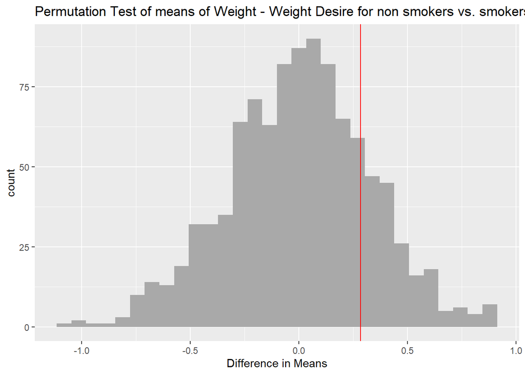

## Conclusion:

We know that there are many determinants of general health, including exercise, diet, sleep, and others. However, weight is a big indicator of one’s general health, i.e. most factors of general health have a large effect on one’s weight. Therefore, this is a good way to determine if smokers are less healthy than non smokers cause someone who is very overweight will have a larger difference in weight vs. weight desire.

## Individual Contributions:

I, Braden Griebel, ran a generalised linear model on the data to see how general health and age affects the probability of the individuals having smoked (at least 100 cigarettes). I used this to understnand how health is affected by smoking when taking into account the age of the individuals (Since general health generally desclines with age). Since the result of the generalised linear model in binomial mode returns logodds I transformed these back into probabilities as those are easier to understand. I added labels, and colored the graph to make it easier to understand. In my individual dection I used a simple linear model to understand how the relation between weight and desired weight changes between the general health categories. I used a facet function to divide between the general health categories when graphing the models. I also displayed the slopes numerically to makae clear how the relationship changed between the difference health categories. Then I used a histogram to display the results of a permutation test (as well as outputting the actual result, and its percentile to make the actual numbers more clear). I used the fill aesthetic to show where in the histogram the tails fell. Finally, I added labels to all the graphs to make clear exactly what each of the graphs meant. The new tooks I applied were a permutation test, and a linear model.

I, Luke Fanning, used a permutation mean test to answer my question regarding smoking and weight difference (weight - weight desired).